# KELOMPOK 4

Excel Muhammad Hendri - M0501261013

Indarto Nurcahyo - M0501261083

Uswatun Hasanah - M0501261021

# **SOAL 1**

> Buat data frame bernama nilai_raw secara manual di R berdasarkan Tabel 1.

```r
nilai_raw <- data.frame(Nama = c("Andi", "Budi", "Citra", "Dewi", "Andi"),
                        Matematika = c(80, 90, NA, 75, 80),
                        Statistika = c(85, 88, 78,"-", 85),
                        Umur = c(21, 20, 22, 21, 21),
                        stringsAsFactors = FALSE)
nilai_raw
```

| Nama | Matematika | Statistika | Umur |
| --- | --- | --- | --- |
| Andi | 80 | 85 | 21 |
| Budi | 90 | 88 | 20 |
| Citra | NA | 78 | 22 |
| Dewi | 75 | - | 21 |
| Andi | 80 | 85 | 21 |

> Identifikasi nilai yang hilang pada dataset secara sistematis. Ubah tanda hubung (“-”) pada nilai Statistika milik Dewi menjadi nilai hilang standar R, yaitu NA.

```r
nilai_raw$Statistika[nilai_raw$Statistika == "-"] <- NA
nilai_raw$Statistika <- as.numeric(nilai_raw$Statistika)
```

> Lakukan imputasi terhadap nilai Statistika yang kosong menggunakan rata-rata nilai Statistika mahasiswa lainnya yang tersedia.

```r
ratarata_stat <- mean(nilai_raw$Statistika, na.rm = TRUE)
nilai_raw$Statistika[is.na(nilai_raw$Statistika)] <- ratarata_stat
nilai_raw
```

| Nama | Matematika | Statistika | Umur |
| --- | --- | --- | --- |
| Andi | 80 | 85 | 21 |
| Budi | 90 | 88 | 20 |
| Citra | NA | 78 | 22 |
| Dewi | 75 | 84 | 21 |
| Andi | 80 | 85 | 21 |

> Buat kolom baru bernama Status_Umur menggunakan fungsi ifelse() dengan ketentuan: Dewasa jika umur ≥ 21 tahun; Muda jika umur < 21 tahun.

```r
nilai_raw$Status_Umur <- ifelse(nilai_raw$Umur >= 21, "Dewasa", "Muda")
nilai_raw
```

| Nama | Matematika | Statistika | Umur | Status_Umur |
| --- | --- | --- | --- | --- |
| Andi | 80 | 85 | 21 | Dewasa |
| Budi | 90 | 88 | 20 | Muda |
| Citra | NA | 78 | 22 | Dewasa |
| Dewi | 75 | 84 | 21 | Dewasa |
| Andi | 80 | 85 | 21 | Dewasa |

> Identifikasi baris pengamatan yang duplikat.

```r
any(duplicated(nilai_raw))
```

```
## [1] TRUE
```

> Menghapus baris pengamatan yang terdapat duplikat.

```r
nilai_raw <- unique(nilai_raw)
nilai_raw
```

|  | Nama | Matematika | Statistika | Umur | Status_Umur |
| --- | --- | --- | --- | --- | --- |
| 1 | Andi | 80 | 85 | 21 | Dewasa |
| 2 | Budi | 90 | 88 | 20 | Muda |
| 3 | Citra | NA | 78 | 22 | Dewasa |
| 4 | Dewi | 75 | 84 | 21 | Dewasa |

> Simpan dataset yang telah dibersihkan ke dalam file bernama nilai_bersih.csv.

```r
write.csv(nilai_raw, file = "nilai_bersih.csv", row.names = FALSE)
getwd()
```

```
## [1] "C:/Users/Excel/OneDrive/Dokumen/Kulyah S2/Semester 1/Pemrograman Statistika/Kel 4 2"
```

# **SOAL 2**

> Buat data frame bernama profil secara manual di R berdasarkan Tabel 2.

```r
profil = data.frame(No = 1:10,
                    Gender = c("f","f","f","m","m","f","m","m","f","m"),
                    v1= c(8,15,8,14,8,10,9,9,10,12),
                    v2= c(9,8,13,9,2,6,9,10,13,10),
                    v3= c(5,9,12,8,9,10,7,8,6,9),
                    v4= c(9,5,6,"NA",16,9,13,10,7,8),
                    v5= c(9,10,7,11,8,10,9,5,10,17),
                    v6= c(9,8,9,10,10,10,12,10,12,7),
                    v7= c(5,10,14,6,8,9,10,6,13,9),
                    v8= c(9,12,12,11,9,7,9,12,9,10),
                    v9= c(11,9,12,11,8,7,11,6,6,7),
                    v10= c(8,15,9,8,9,11,7,8,9,7),
                    stringsAsFactors = FALSE)
profil
```

| No | Gender | v1 | v2 | v3 | v4 | v5 | v6 | v7 | v8 | v9 | v10 |
| --- | --- | --- | --- | --- | --- | --- | --- | --- | --- | --- | --- |
| 1 | f | 8 | 9 | 5 | 9 | 9 | 9 | 5 | 9 | 11 | 8 |
| 2 | f | 15 | 8 | 9 | 5 | 10 | 8 | 10 | 12 | 9 | 15 |
| 3 | f | 8 | 13 | 12 | 6 | 7 | 9 | 14 | 12 | 12 | 9 |
| 4 | m | 14 | 9 | 8 | NA | 11 | 10 | 6 | 11 | 11 | 8 |
| 5 | m | 8 | 2 | 9 | 16 | 8 | 10 | 8 | 9 | 8 | 9 |
| 6 | f | 10 | 6 | 10 | 9 | 10 | 10 | 9 | 7 | 7 | 11 |
| 7 | m | 9 | 9 | 7 | 13 | 9 | 12 | 10 | 9 | 11 | 7 |
| 8 | m | 9 | 10 | 8 | 10 | 5 | 10 | 6 | 12 | 6 | 8 |
| 9 | f | 10 | 13 | 6 | 7 | 10 | 12 | 13 | 9 | 6 | 9 |
| 10 | m | 12 | 10 | 9 | 8 | 17 | 7 | 9 | 10 | 7 | 7 |

> Lakukan penyaringan (subsetting) sehingga hanya menyisakan pengamatan yang memenuhi salah satu kondisi berikut: gender laki-laki (m) dan v1 > 9 ; atau gender perempuan (f) dan v3 <= 10

```r
myprofil <- ((profil$Gender == "m" & profil$v1>9)|(profil$Gender == "f" & profil$v3 <= 10))
profil_filter <- profil[myprofil,]
profil_filter
```

|  | No | Gender | v1 | v2 | v3 | v4 | v5 | v6 | v7 | v8 | v9 | v10 |
| --- | --- | --- | --- | --- | --- | --- | --- | --- | --- | --- | --- | --- |
| 1 | 1 | f | 8 | 9 | 5 | 9 | 9 | 9 | 5 | 9 | 11 | 8 |
| 2 | 2 | f | 15 | 8 | 9 | 5 | 10 | 8 | 10 | 12 | 9 | 15 |
| 4 | 4 | m | 14 | 9 | 8 | NA | 11 | 10 | 6 | 11 | 11 | 8 |
| 6 | 6 | f | 10 | 6 | 10 | 9 | 10 | 10 | 9 | 7 | 7 | 11 |
| 9 | 9 | f | 10 | 13 | 6 | 7 | 10 | 12 | 13 | 9 | 6 | 9 |
| 10 | 10 | m | 12 | 10 | 9 | 8 | 17 | 7 | 9 | 10 | 7 | 7 |

```r
library(dplyr)
profil_filter <- profil %>% arrange(desc(profil$Gender), profil$v5)

profil_filter
```

| No | Gender | v1 | v2 | v3 | v4 | v5 | v6 | v7 | v8 | v9 | v10 |
| --- | --- | --- | --- | --- | --- | --- | --- | --- | --- | --- | --- |
| 8 | m | 9 | 10 | 8 | 10 | 5 | 10 | 6 | 12 | 6 | 8 |
| 5 | m | 8 | 2 | 9 | 16 | 8 | 10 | 8 | 9 | 8 | 9 |
| 7 | m | 9 | 9 | 7 | 13 | 9 | 12 | 10 | 9 | 11 | 7 |
| 4 | m | 14 | 9 | 8 | NA | 11 | 10 | 6 | 11 | 11 | 8 |
| 10 | m | 12 | 10 | 9 | 8 | 17 | 7 | 9 | 10 | 7 | 7 |
| 3 | f | 8 | 13 | 12 | 6 | 7 | 9 | 14 | 12 | 12 | 9 |
| 1 | f | 8 | 9 | 5 | 9 | 9 | 9 | 5 | 9 | 11 | 8 |
| 2 | f | 15 | 8 | 9 | 5 | 10 | 8 | 10 | 12 | 9 | 15 |
| 6 | f | 10 | 6 | 10 | 9 | 10 | 10 | 9 | 7 | 7 | 11 |
| 9 | f | 10 | 13 | 6 | 7 | 10 | 12 | 13 | 9 | 6 | 9 |

> Menyimpan file data dengan nama profil_filter dalam bentuk format csv

```r
write.csv(profil_filter, file = "profil_filter.csv", row.names = FALSE)
getwd()
```

```
## [1] "C:/Users/Excel/OneDrive/Dokumen/Kulyah S2/Semester 1/Pemrograman Statistika/Kel 4 2"
```

# **SOAL 3**

> Gabungkan df_sales dan df_info menggunakan fungsi merge() dengan metode Full Outer Join, sehingga seluruh toko dari kedua data frame tetap disertakan. Perhatikan bahwa nama variabel kunci pada kedua data frame berbeda, yaitu id_toko pada df_sales dan id pada df_info. Gunakan argumen penggabungan yang sesuai.

```r
df_sales <- data.frame(
  id_toko = c("T1", "T2", "T3"),
  Minggu1 = c(120, 150, 95),
  Minggu2 = c(135, 140, 110)
)

df_info <- data.frame(
  id = c("T1", "T2", "T4"),
  Kota = c("Jakarta", "Bandung", "Surabaya")
)

df_merged <- merge(
  df_sales,
  df_info,
  by.x = "id_toko",
  by.y = "id",
  all = TRUE
)
df_merged
```

| id_toko | Minggu1 | Minggu2 | Kota |
| --- | --- | --- | --- |
| T1 | 120 | 135 | Jakarta |
| T2 | 150 | 140 | Bandung |
| T3 | 95 | 110 | NA |
| T4 | NA | NA | Surabaya |

> Ubah struktur data hasil penggabungan dari format Wide menjadi Long, sehingga: Minggu1 dan Minggu2 digabung menjadi satu kolom bernama Waktu; nilai penjualan disimpan dalam satu kolom bernama Penjualan.

```r
# 1. Transformasi menggunakan reshape
df_long <- reshape(
  df_merged,
  varying = c("Minggu1", "Minggu2"),
  v.names = "Penjualan",
  timevar = "Waktu",
  times = c("Minggu1", "Minggu2"),
  direction = "long"
)
df_long <- df_long[, c("id", "id_toko", "Kota", "Waktu", "Penjualan")]
rownames(df_long) <- NULL
df_long
```

| id | id_toko | Kota | Waktu | Penjualan |
| --- | --- | --- | --- | --- |
| 1 | T1 | Jakarta | Minggu1 | 120 |
| 2 | T2 | Bandung | Minggu1 | 150 |
| 3 | T3 | NA | Minggu1 | 95 |
| 4 | T4 | Surabaya | Minggu1 | NA |
| 1 | T1 | Jakarta | Minggu2 | 135 |
| 2 | T2 | Bandung | Minggu2 | 140 |
| 3 | T3 | NA | Minggu2 | 110 |
| 4 | T4 | Surabaya | Minggu2 | NA |

```r
write.csv(df_long, file = "penjualan_long.csv", row.names = FALSE)
getwd()
```

```
## [1] "C:/Users/Excel/OneDrive/Dokumen/Kulyah S2/Semester 1/Pemrograman Statistika/Kel 4 2"
```

# **SOAL 4**

> Kenali struktur dataset CO2 dan identifikasi peran peubah Plant, Type, Treatment, conc, dan uptake, kemudian buat grafik menggunakan base R untuk menunjukkan hubungan conc dan uptake dengan mengatur bentuk dan ukuran titik, warna, judul, label sumbu, serta rentang sumbu, lalu tambahkan minimal dua elemen grafik menggunakan points(), lines(), abline(), atau text().

```r
CO2
```

|  | Plant | Type | Treatment | conc | uptake |
| --- | --- | --- | --- | --- | --- |
| 1 | Qn1 | Quebec | nonchilled | 95 | 16.0 |
| 2 | Qn1 | Quebec | nonchilled | 175 | 30.4 |
| 3 | Qn1 | Quebec | nonchilled | 250 | 34.8 |
| 4 | Qn1 | Quebec | nonchilled | 350 | 37.2 |
| 5 | Qn1 | Quebec | nonchilled | 500 | 35.3 |
| 6 | Qn1 | Quebec | nonchilled | 675 | 39.2 |
| 7 | Qn1 | Quebec | nonchilled | 1000 | 39.7 |
| 8 | Qn2 | Quebec | nonchilled | 95 | 13.6 |
| 9 | Qn2 | Quebec | nonchilled | 175 | 27.3 |
| 10 | Qn2 | Quebec | nonchilled | 250 | 37.1 |

[output cut: 74 more lines]

```r
str(CO2)
```

```
## Classes 'nfnGroupedData', 'nfGroupedData', 'groupedData' and 'data.frame':   84 obs. of  5 variables:
##  $ Plant    : Ord.factor w/ 12 levels "Qn1"<"Qn2"<"Qn3"<..: 1 1 1 1 1 1 1 2 2 2 ...
##  $ Type     : Factor w/ 2 levels "Quebec","Mississippi": 1 1 1 1 1 1 1 1 1 1 ...
##  $ Treatment: Factor w/ 2 levels "nonchilled","chilled": 1 1 1 1 1 1 1 1 1 1 ...
##  $ conc     : num  95 175 250 350 500 675 1000 95 175 250 ...
##  $ uptake   : num  16 30.4 34.8 37.2 35.3 39.2 39.7 13.6 27.3 37.1 ...
##  - attr(*, "formula")=Class 'formula'  language uptake ~ conc | Plant
##   .. ..- attr(*, ".Environment")=<environment: R_EmptyEnv>
##  - attr(*, "outer")=Class 'formula'  language ~Treatment * Type
##   .. ..- attr(*, ".Environment")=<environment: R_EmptyEnv>
##  - attr(*, "labels")=List of 2
##   ..$ x: chr "Ambient carbon dioxide concentration"
##   ..$ y: chr "CO2 uptake rate"
##  - attr(*, "units")=List of 2
##   ..$ x: chr "(uL/L)"
##   ..$ y: chr "(umol/m^2 s)"
```

```r
summary(CO2)
```

```
##      Plant             Type         Treatment       conc          uptake
##  Qn1    : 7   Quebec     :42   nonchilled:42   Min.   :  95   Min.   : 7.70
##  Qn2    : 7   Mississippi:42   chilled   :42   1st Qu.: 175   1st Qu.:17.90
##  Qn3    : 7                                    Median : 350   Median :28.30
##  Qc1    : 7                                    Mean   : 435   Mean   :27.21
##  Qc3    : 7                                    3rd Qu.: 675   3rd Qu.:37.12
##  Qc2    : 7                                    Max.   :1000   Max.   :45.50
##  (Other):42
```

> Melihat hubungan conc dengan uptake

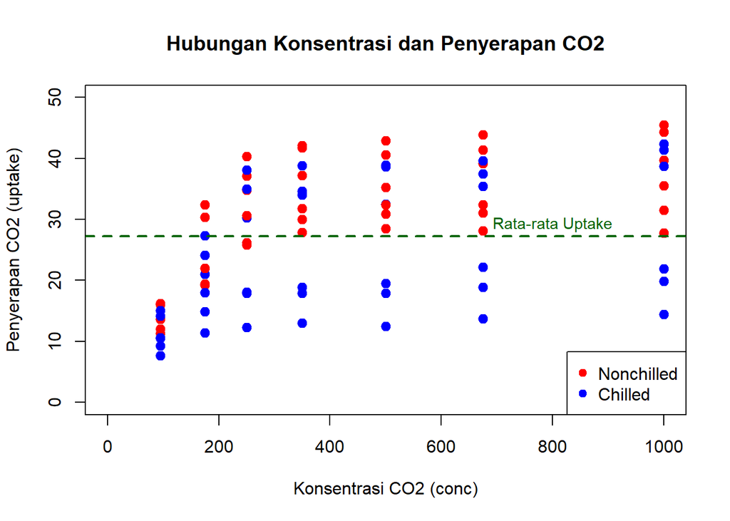

```r
plot(
  CO2$conc, CO2$uptake,
  pch = 19,
  cex = 1.2,
  col = ifelse(CO2$Treatment == "chilled", "blue", "red"),
  main = "Hubungan Konsentrasi dan Penyerapan CO2",
  xlab = "Konsentrasi CO2 (conc)",
  ylab = "Penyerapan CO2 (uptake)",
  xlim = c(0, 1000),
  ylim = c(0, 50)
)
abline(h = mean(CO2$uptake), col = "darkgreen", lty = 2, lwd = 2)
text(x = 800, y = mean(CO2$uptake) + 2, labels = "Rata-rata Uptake", col = "darkgreen", cex = 0.9)
legend("bottomright", legend = c("Nonchilled", "Chilled"), col = c("red", "blue"), pch = 19)
```

> Buat satu tampilan grafik berukuran 2 × 2 yang terdiri atas empat jenis visualisasi berbeda untuk mengeksplorasi conc, uptake, Type, dan Treatment; tentukan sendiri jenis grafik yang paling sesuai dan berikan judul yang jelas pada setiap grafik.

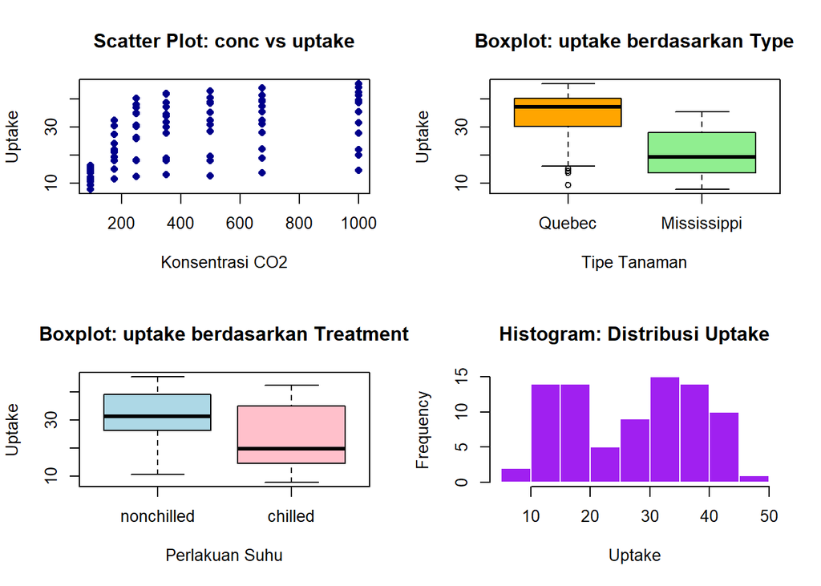

```r
par(mfrow = c(2, 2))

# Grafik 1: Scatter Plot conc vs uptake
plot(CO2$conc, CO2$uptake, main = "Scatter Plot: conc vs uptake",
     xlab = "Konsentrasi CO2", ylab = "Uptake", col = "darkblue", pch = 16)

# Grafik 2: Boxplot uptake berdasarkan Type
boxplot(uptake ~ Type, data = CO2, main = "Boxplot: uptake berdasarkan Type",
        xlab = "Tipe Tanaman", ylab = "Uptake", col = c("orange", "lightgreen"))

# Grafik 3: Boxplot uptake berdasarkan Treatment
boxplot(uptake ~ Treatment, data = CO2, main = "Boxplot: uptake berdasarkan Treatment",
        xlab = "Perlakuan Suhu", ylab = "Uptake", col = c("lightblue", "pink"))

# Grafik 4: Histogram Distribusi uptake
hist(CO2$uptake, main = "Histogram: Distribusi Uptake",
     xlab = "Uptake", col = "purple", border = "white")
```

> Gunakan qplot() untuk membuat visualisasi cepat hubungan conc dan uptake berdasarkan Treatment, kemudian buat kembali visualisasi tersebut menggunakan ggplot2 dengan memetakan Treatment dan Type ke atribut visual yang berbeda di dalam aes() serta menggunakan geom_* yang sesuai.

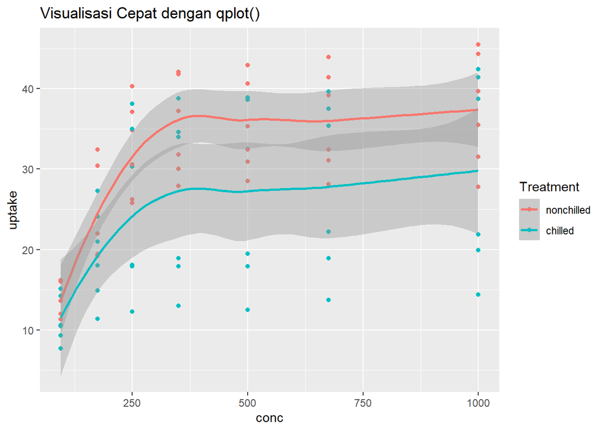

```r
library(ggplot2)
qplot(x = conc, y = uptake, data = CO2, color = Treatment,
      geom = c("point", "smooth"),
      main = "Visualisasi Cepat dengan qplot()")
```

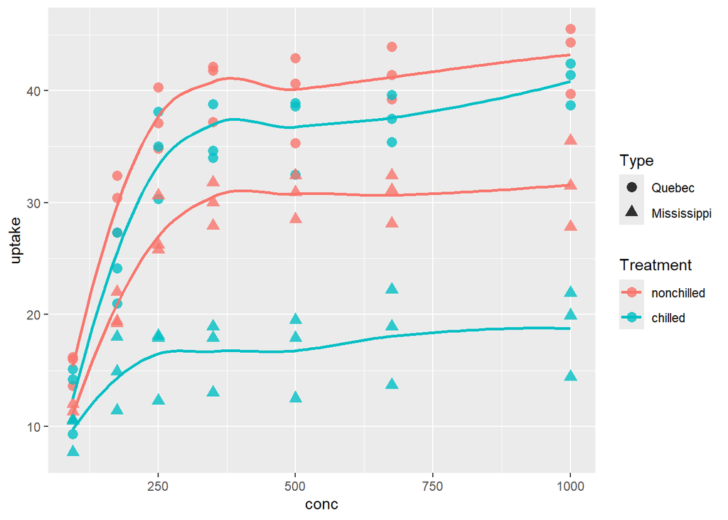

```r
# Visualisasi Ulang dengan ggplot2 (Pemetaan Treatment dan Type)
p_base <- ggplot(CO2, aes(x = conc, y = uptake, color = Treatment, shape = Type)) +
  geom_point(size = 3, alpha = 0.8) +
  geom_smooth(method = "loess", se = FALSE)
p_base
```

> **Interpretasi**

> Berdasarkan grafi di atas, terlihat peningkatan pada tingkat penyerapan (*Uptake*) atau dengan kata lain terdapat penyerapan $\text{CO}_2$ meningkat pesat. Namun, pada tingkat konsentrasi mengalami stagnan pada kisaran 300 hingga 1000. Sehingga dapat disimpulkan bahwa meskipun pasokan $\text{CO}_2$ terus bertambah hingga 1000 tingakt penyerapan (*Uptake*) stagnan atau teteap berada di level yang sama karena kapasitas penyerapan tanaman telah mencapai titik jenuh.

> Kembangkan grafik ggplot2 tersebut dengan menambahkan minimal satu stat_*, satu scale_*, serta salah satu coord_*, kemudian lengkapi grafik menggunakan labs() dan theme() atau salah satu tema siap pakai agar grafik lebih informatif dan mudah dibaca.

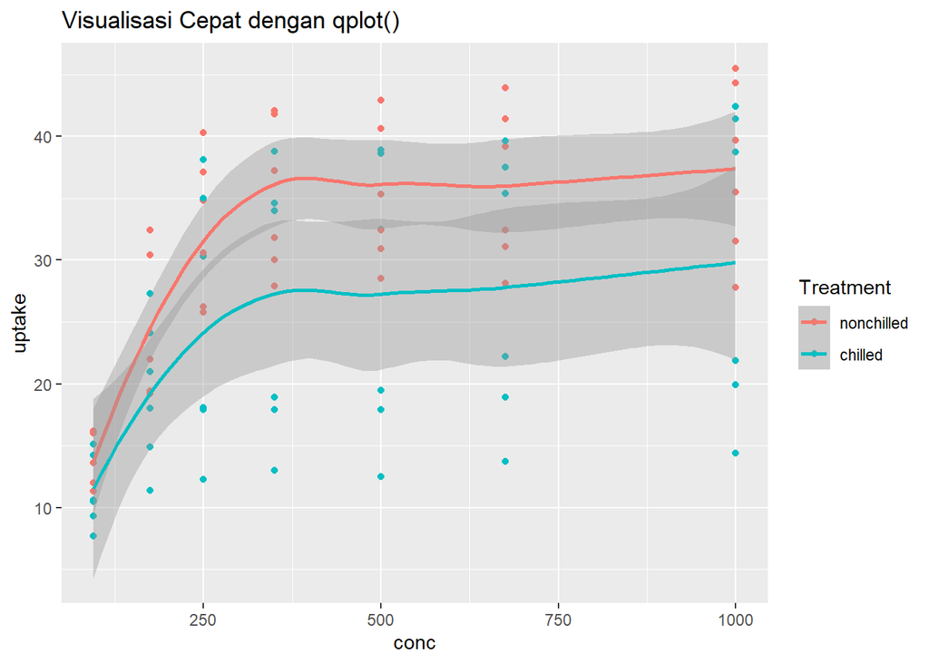

```r
library(ggplot2)

# Visualisasi Cepat dengan qplot()
qplot(x = conc, y = uptake, data = CO2, color = Treatment,
      geom = c("point", "smooth"),
      main = "Visualisasi Cepat dengan qplot()")
```

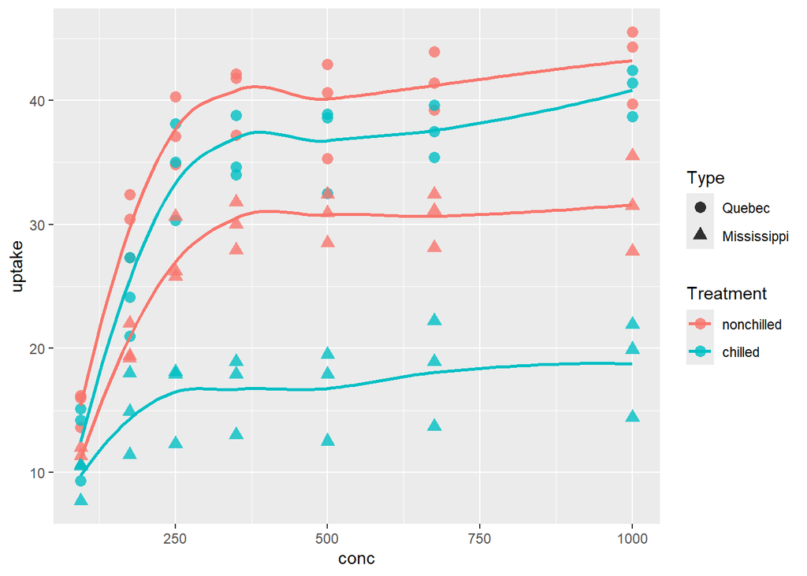

```r
p_base <- ggplot(CO2, aes(x = conc, y = uptake, color = Treatment, shape = Type)) +
  geom_point(size = 3, alpha = 0.8) +
  geom_smooth(method = "loess", se = FALSE)
p_base
```

> Simpan grafik akhir menggunakan ggsave() dalam format PNG dengan nama co2_uptake_visualisasi.png, kemudian tuliskan interpretasi mengenai hubungan antara konsentrasi CO₂ dan uptake serta perbedaan pola yang terlihat berdasarkan Type dan Treatment.

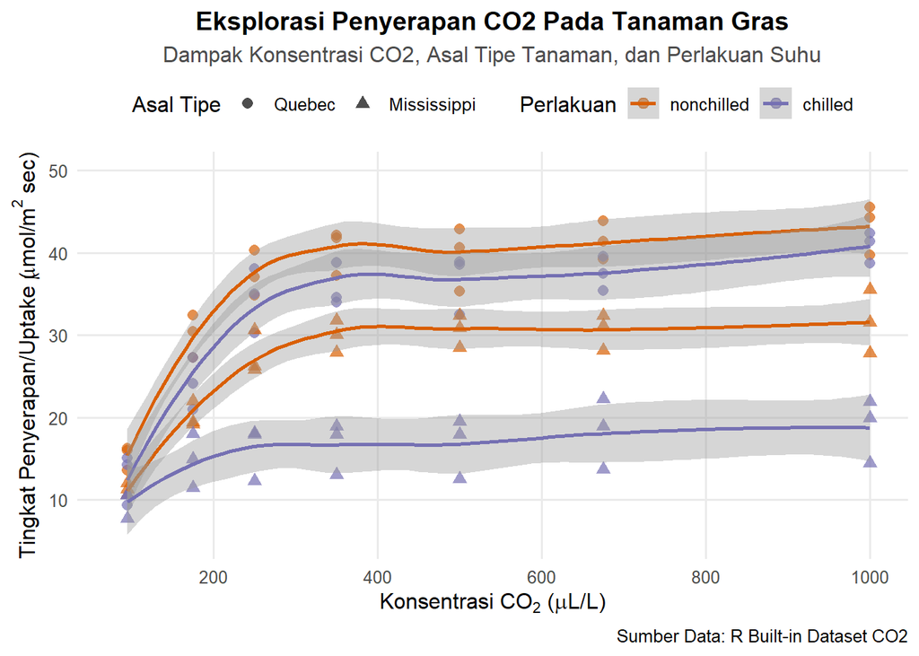

```r
# Pengembangan grafik lengkap
p_final <- ggplot(CO2, aes(x = conc, y = uptake, color = Treatment, shape = Type)) +
  geom_point(size = 2.5, alpha = 0.7) +
  stat_smooth(method = "loess", se = TRUE, size = 1) +
  scale_color_manual(values = c("nonchilled" = "#D95F02", "chilled" = "#7570B3")) +
  scale_shape_manual(values = c("Quebec" = 16, "Mississippi" = 17)) +
  scale_x_continuous(breaks = seq(0, 1000, by = 200)) +
  coord_cartesian(xlim = c(80, 1000), ylim = c(5, 50)) +
  labs(
    title = "Eksplorasi Penyerapan CO2 Pada Tanaman Gras",
    subtitle = "Dampak Konsentrasi CO2, Asal Tipe Tanaman, dan Perlakuan Suhu",
    x = expression(paste("Konsentrasi ", CO[2], " (", mu, "L/L)")),
    y = expression(paste("Tingkat Penyerapan/Uptake (", mu, "mol/", m^2, " sec)")),
    color = "Perlakuan",
    shape = "Asal Tipe",
    caption = "Sumber Data: R Built-in Dataset CO2"
  ) +

  theme_minimal(base_size = 12) +
  theme(
    plot.title = element_text(face = "bold", size = 14, hjust = 0.5),
    plot.subtitle = element_text(hjust = 0.5, color = "gray30"),
    legend.position = "top",
    panel.grid.minor = element_blank()
  )
print(p_final)
```

> **Interpretasi**

> Berdasarkan grafik di atas, menunjukkan bahwa kemampuan tanaman dalam menyerap $\text{CO}_2$ dipengaruhi oleh konsentrasi $\text{CO}_2$, daerah asal, dan suhu lingkungan. Penyerapan $\text{CO}_2$ melonjak pesat di awal pada kadar $95\text{--}250\ \mu\text{L/L}$, tetapi mulai stagnan atau mendatar setelah melewati kadar $350\ \mu\text{L/L}$. Tanaman asal **Quebec** (titik bulat) jauh lebih jago menyerap $\text{CO}_2$ dan tahan suhu dingin dibandingkan tanaman **Mississippi** (titik segitiga), sementara paparan suhu dingin (*Chilled*, garis ungu) terbukti menurunkan penyerapan pada kedua jenis tanaman. Sehingga, tanaman Mississippi yang didinginkan menjadi yang paling parah penyerapannya, sedangkan tanaman Quebec sangat tahan dingin karena saat kedinginan pun penyerapannya masih lebih tinggi daripada tanaman Mississippi di suhu normal (*Nonchilled*, garis oranye).

> Menyimpan grafik akhir menggunakan ggsave()

```r
ggsave(
  filename = "co2_uptake_visualisasi.png",
  plot = p_final,
  width = 8,
  height = 6,
  dpi = 300
)
```